# Part I - (Dataset Exploration Title)

For the purpose of this project where I may not be making use of some of these columns, I will be dropping the columns I won't be using.

```python
#dropping columns that have more than 50% missingness and won't be used in the exploratory and explanatory process
loan.drop(['CreditGrade', 'GroupKey', 'OnTimeProsperPayments', 'ProsperPaymentsLessThanOneMonthLate',
           'ProsperPaymentsOneMonthPlusLate', 'ProsperPrincipalBorrowed', 'ProsperPrincipalOutstanding',
           'ScorexChangeAtTimeOfListing', 'LoanFirstDefaultedCycleNumber'], axis=1, inplace=True)
```

After taking time to thoroughly check columns with missing values that will be used during the analysis process, some rows of these columns that don't have a high percentage of missingness will be dropped while others that are missing not at random will be filled with specific values

```python
#get columns with missing value percentages greater than 0%
Missing_Percentage[Missing_Percentage>0]
```

```
CreditGrade                            74.588588
ClosedDate                             51.649596
BorrowerAPR                             0.021942
EstimatedEffectiveYield                25.526387
EstimatedLoss                          25.526387
EstimatedReturn                        25.526387
ProsperRating (numeric)                25.526387
ProsperRating (Alpha)                  25.526387
ProsperScore                           25.526387
BorrowerState                           4.840394
Occupation                              3.149109
EmploymentStatus                        1.979164
EmploymentStatusDuration                6.692295
GroupKey                               88.290898
CreditScoreRangeLower                   0.518708
CreditScoreRangeUpper                   0.518708
FirstRecordedCreditLine                 0.611742
CurrentCreditLines                      6.673864
OpenCreditLines                         6.673864
TotalCreditLinespast7years              0.611742
InquiriesLast6Months                    0.611742
TotalInquiries                          1.017229
CurrentDelinquencies                    0.611742
AmountDelinquent                        6.689662
DelinquenciesLast7Years                 0.868901
PublicRecordsLast10Years                0.611742
PublicRecordsLast12Months               6.673864
RevolvingCreditBalance                  6.673864
BankcardUtilization                     6.673864
AvailableBankcardCredit                 6.621203
TotalTrades                             6.621203
TradesNeverDelinquent (percentage)      6.621203
TradesOpenedLast6Months                 6.621203
DebtToIncomeRatio                       7.507658
TotalProsperLoans                      80.616481
TotalProsperPaymentsBilled             80.616481
OnTimeProsperPayments                  80.616481
ProsperPaymentsLessThanOneMonthLate    80.616481
ProsperPaymentsOneMonthPlusLate        80.616481
ProsperPrincipalBorrowed               80.616481
ProsperPrincipalOutstanding            80.616481
ScorexChangeAtTimeOfListing            83.387311
LoanFirstDefaultedCycleNumber          85.121602
dtype: float64
```

```python
#dropping specific rows in the columns that don't have a high percentage of missingness
loan.drop(loan[(loan['CreditScoreRangeLower'].isnull()==True) | (loan['CreditScoreRangeUpper'].isnull()==True)
              | (loan['EmploymentStatus'].isnull()==True) | (loan['EmploymentStatusDuration'].isnull()==True)
              | (loan['Occupation'].isnull()==True) | (loan['CurrentDelinquencies'].isnull()==True) |
              (loan['DebtToIncomeRatio'].isnull()==True)| (loan['IncomeRange']=='Not displayed')].index, inplace=True)
```

```python
#confirming they've been dropped
Missing1=loan.isnull().sum()
TotalMissing1=Missing1[Missing1>0]
#pring out the columns
TotalMissing1
```

```
ClosedDate                            53200
EstimatedEffectiveYield               20206
EstimatedLoss                         20206
EstimatedReturn                       20206
ProsperRating (numeric)               20206
ProsperRating (Alpha)                 20206
ProsperScore                          20206
BorrowerState                          1679
CurrentCreditLines                        1
OpenCreditLines                           1
PublicRecordsLast12Months                 1
RevolvingCreditBalance                    1
BankcardUtilization                       1
AvailableBankcardCredit                   1
TotalTrades                               1
TradesNeverDelinquent (percentage)        1
TradesOpenedLast6Months                   1
TotalProsperLoans                     76535
TotalProsperPaymentsBilled            76535
dtype: int64
```

According to the description attached to the TotalProsperLoans and TotalProsperPayments Billed column, it was specifically stated that "This value will be null if the borrower had no prior loans", for this reason, I will be filling the null rows with 0

```python
#filling missing rows with 0 in the TotalProsperLoans and TotalProsperPaymentsBilled and ProsperScore columns
loan['TotalProsperLoans'].fillna(0.0, inplace=True)
loan['TotalProsperPaymentsBilled'].fillna(0.0, inplace=True)
loan['ProsperScore'].fillna(0.0, inplace=True)
```

```python
#converting the ClosedDate Column to Datetime column
loan['ClosedDate'] = pd.to_datetime(loan['ClosedDate'])
```

```python
#converting some Columns to integers column
coldata=['TotalProsperLoans', 'TotalProsperPaymentsBilled', 'CurrentDelinquencies', 'EmploymentStatusDuration',
        'CreditScoreRangeLower', 'CreditScoreRangeUpper', 'ProsperScore']
for data in coldata:
    loan[data]=loan[data].astype('int')
```

```python
loan['TotalProsperLoans'].dtypes
```

```
dtype('int64')
```

```python
#converting the EmploymentStatus and Occupation columns to Categorical and Object type columns
loan['EmploymentStatus'] = loan['EmploymentStatus'].astype('category')
loan['Occupation'] = loan['Occupation'].astype('object')
```

```python
# convert IncomeRange and LoanStatus into ordered categorical types
ordinal_var_dict = {'IncomeRange': ['Not employed','$1-24,999 ','$25,000-49,999',
                                    '$50,000-74,999','$75,000-99,999', '$100,000+'],
                    'LoanStatus': ['Current', 'Completed', 'FinalPaymentProgress',
                                   'Past Due (1-15 days)', 'Past Due (16-30 days)',
                                   'Past Due (31-60 days)', 'Past Due (61-90 days)',
                                   'Past Due (91-120 days)', 'Chargedoff', 'Defaulted', 'Cancelled']}

for var in ordinal_var_dict:
    pd_ver = pd.__version__.split(".")
    if (int(pd_ver[0]) > 0) or (int(pd_ver[1]) >= 21): # v0.21 or later
        ordered_var = pd.api.types.CategoricalDtype(ordered = True,
                                                    categories = ordinal_var_dict[var])
        loan[var] = loan[var].astype(ordered_var)
    else: # pre-v0.21
        loan[var] = loan[var].astype('category', ordered = True,
                                             categories = ordinal_var_dict[var])
```

### What is/are the main feature(s) of interest in your dataset?

> I'm most interested in figuring out what features are best for predicting the Loan Amounts and Borrower Rate in the dataset

### What features in the dataset do you think will help support your investigation into your feature(s) of interest?

> I expect that for Borrower Rate, "CreditScoreRangeLower", "CreditScoreRangeUpper", "EmploymentStatus", "IncomeRange" and "DebtToIncomeRatio" will have noticeable effects. For Loan Amount, I expect it to be affected by "StatedMonthlyIncome", "EmploymentStatus", "EmploymentStatusDuration", "Occupation", "ListingCategory", "ProsperScore".

## Univariate Exploration

> In this section, investigate distributions of individual variables. If you see unusual points or outliers, take a deeper look to clean things up and prepare yourself to look at relationships between variables.

> **Rubric Tip**: The project (Parts I alone) should have at least 15 visualizations distributed over univariate, bivariate, and multivariate plots to explore many relationships in the data set. Use reasoning to justify the flow of the exploration.

> **Rubric Tip**: Use the "Question-Visualization-Observations" framework throughout the exploration. This framework involves **asking a question from the data, creating a visualization to find answers, and then recording observations after each visualisation.**

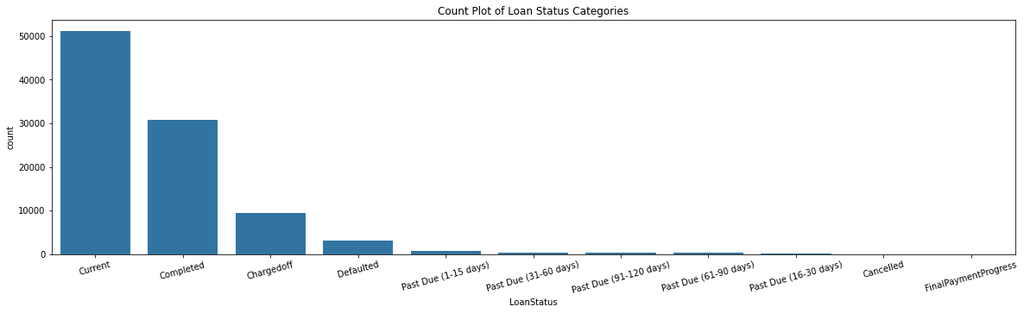

```python
# start with a standard-scaled plot
# Choose the first tuple of RGB colors
base_color = sb.color_palette()[0]

freq = loan['LoanStatus'].value_counts()

# Get the indexes of the Series
gen_order = freq.index

# Set a larger figure size for subplots
plt.figure(figsize = [20, 5])

# Plot the bar chart in the decreasing order of the frequency of the `generation_id`
sb.countplot(data=loan, x='LoanStatus', color=base_color, order=gen_order)

# Use xticks to rotate the category labels (not axes) counter-clockwise
plt.xticks(rotation=15)
plt.title("Count Plot of Loan Status Categories")
```

In the bar chart above, past due has been sub-divided further, therefore, to have an overall look at the data, I will be combining them into just one value

```python
#creating a copy of the loanstatus column so that the LoanStatus column doesn't get affected
loan['LoanStatusCopy']=loan['LoanStatus'].copy()
```

```python
#combining the past dues into one value, "past due"
loan['LoanStatusCopy'].replace(['Past Due (1-15 days)', 'Past Due (16-30 days)', 'Past Due (31-60 days)',
                                'Past Due (61-90 days)', 'Past Due (91-120 days)',
                                'Past Due (>120 days)'],'Past Due', inplace=True)
```

```python
loan['LoanStatus'].value_counts()
```

```
Current                   51170
Completed                 30769
Chargedoff                 9398
Defaulted                  3054
Past Due (1-15 days)        714
Past Due (31-60 days)       322
Past Due (91-120 days)      277
Past Due (61-90 days)       275
Past Due (16-30 days)       241
Cancelled                     1
FinalPaymentProgress          0
Name: LoanStatus, dtype: int64
```

```python
#confirming the combination has been made
loan['LoanStatusCopy'].value_counts()
```

```
Current       51170
Completed     30769
Chargedoff     9398
Defaulted      3054
Past Due       1829
Cancelled         1
Name: LoanStatusCopy, dtype: int64
```

```python
#getting the distribution of the different Loan Status categories spread across the dataset in percentage
loanstatusper=(loan['LoanStatusCopy'].value_counts().values/loan['LoanStatusCopy'].value_counts().values.sum())*100
loanstatusper
```

```
array([5.31796593e+01, 3.19774270e+01, 9.76709866e+00, 3.17394332e+00,
       1.90083246e+00, 1.03927417e-03])
```

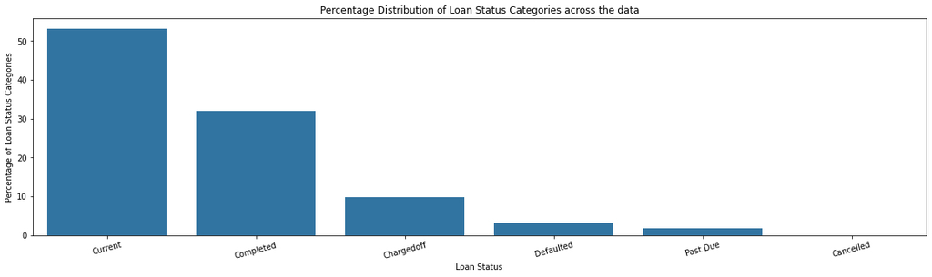

```python
# start with a standard-scaled plot
# Choose the first tuple of RGB colors
base_color = sb.color_palette()[0]


freq = loan['LoanStatusCopy'].value_counts()

# Get the indexes of the Series
gen_order = freq.index

# Set a larger figure size for subplots
plt.figure(figsize = [20, 5])

# Plot the bar chart in the decreasing order of the frequency of the `generation_id`
sb.barplot(x=loan['LoanStatusCopy'].value_counts().index, y=loanstatusper, color=base_color, order=gen_order)

# Use xticks to rotate the category labels (not axes) counter-clockwise
plt.xticks(rotation=15)

#labeling the x and y axis
plt.xlabel("Loan Status")
plt.ylabel("Percentage of Loan Status Categories")
plt.title("Percentage Distribution of Loan Status Categories across the data")
```

It was obsered across the data that more than 50% of the loans recorded were current loans, 32% were completed loans, 9.8% were charged off loans, 3% were defaulting, 2% past due, less than 1% were cancelled and had Final Payment in Progress

```python
#getting the statistics of the BorrowerRate column to get a binsize and minimum bins for plotting
loan['BorrowerRate'].describe()
```

```
count    96422.000000
mean         0.190853
std          0.074628
min          0.000000
25%          0.131400
50%          0.180000
75%          0.249200
max          0.360000
Name: BorrowerRate, dtype: float64
```

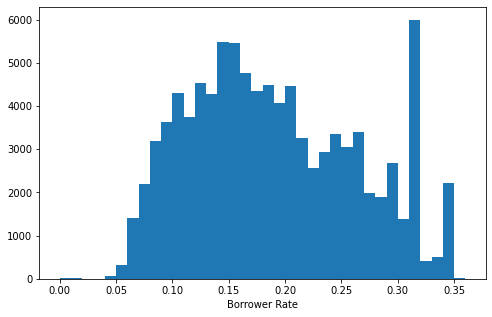

```python
# start with a standard-scaled plot
binsize = 0.01
bins = np.arange(0, loan['BorrowerRate'].max()+binsize, binsize)

#setting chart size
plt.figure(figsize=[8, 5])
#plotting the histogram of BorrowerRate using the created bins
plt.hist(data = loan, x = 'BorrowerRate', bins = bins)
#labelling the x-axis
plt.xlabel('Borrower Rate')
plt.show()
```

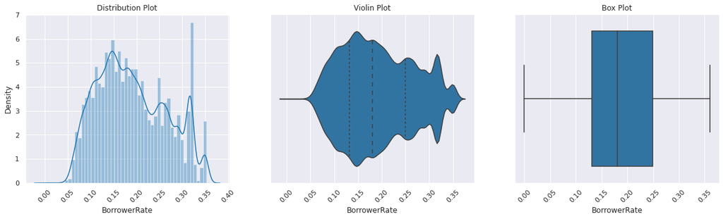

```python
plt.figure(figsize = [20, 5])
base_color = sb.color_palette()[0]

sb.set(style="darkgrid")

# Second plot: Distribution Plot with KDE
plt.subplot(1, 3, 1)
plt.title("Distribution Plot")
sb.distplot(loan['BorrowerRate'], color=base_color)
plt.xticks(rotation = 45)# include label rotation due to small subplot size
plt.ylabel('Density');

#Third plot: Violin plot
plt.subplot(1, 3, 2)
plt.title("Violin Plot")
sb.violinplot(data = loan, x='BorrowerRate', inner="quartile", color=base_color)
plt.xticks(rotation = 45); # include label rotation due to small subplot size

# Fourth plot: Box Plot
plt.subplot(1, 3, 3)
plt.title("Box Plot")
sb.boxplot(data = loan, x='BorrowerRate', orient='v', color=base_color)
plt.xticks(rotation = 45); # include label rotation due to small subplot size
```

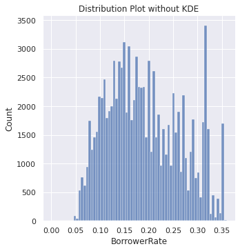

```python
# leftmost plot: Distribution Plot without KDE
plt.figure(figsize = [30, 15])
sb.displot(loan['BorrowerRate'], kind='hist')
plt.title("Distribution Plot without KDE")
plt.ylabel('Count')
```

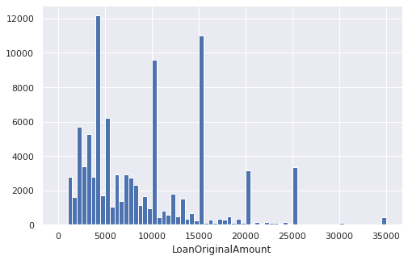

```python
# start with a standard-scaled plot
binsize = 500
bins = np.arange(0, loan['LoanOriginalAmount'].max()+binsize, binsize)

plt.figure(figsize=[8, 5])
plt.hist(data = loan, x = 'LoanOriginalAmount', bins = bins)
plt.xlabel('LoanOriginalAmount')
plt.show()
```

```python
np.log10(loan['LoanOriginalAmount'].describe())
```

```
count    4.984176
mean     3.939994
std      3.804239
min      3.000000
25%      3.602060
50%      3.845098
75%      4.096910
max      4.544068
Name: LoanOriginalAmount, dtype: float64
```

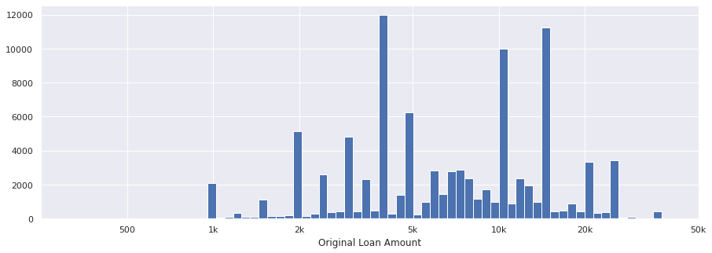

```python
# there's a long tail in the distribution, so let's put it on a log scale instead
base_color = sb.color_palette()[0]
log_binsize = 0.03
bins = 10 ** np.arange(2.5, np.log10(loan['LoanOriginalAmount'].max())+log_binsize, log_binsize)

plt.figure(figsize=[15, 5])
plt.hist(data = loan, x='LoanOriginalAmount', bins = bins, color=base_color)
plt.xscale('log')
plt.xticks([500, 1e3, 2e3, 5e3, 1e4, 2e4, 5e4], [500, '1k', '2k', '5k', '10k', '20k', '50k'])
plt.xlabel('Original Loan Amount')
plt.show()
```

At first glance at the loan amount, it seemed as if it was positively skewed but after log-scaling the loan amount and taking a second look, it became clearer that theres no skewness but at some certain points, the number of loans for loan amounts seemed to increase suddenly and dropped as fast as they increased.

> **Rubric Tip**: Visualizations should depict the data appropriately so that the plots are easily interpretable. You should choose an appropriate plot type, data encodings, and formatting as needed. The formatting may include setting/adding the title, labels, legend, and comments. Also, do not overplot or incorrectly plot ordinal data.

### Discuss the distribution(s) of your variable(s) of interest. Were there any unusual points? Did you need to perform any transformations?

> Of the variables of Interest, Loan Original Amount and Borrower Rate had interesting distributions. At first, Loan Amount seemed to be positively skewed but after log transformation, it became obvious that there was no skewness. As for the Borrower Rate, the distribution was positively skewed and didn'thave need for any form of transformation.

### Of the features you investigated, were there any unusual distributions? Did you perform any operations on the data to tidy, adjust, or change the form of the data? If so, why did you do this?

> For Loan Status, owing to the spread of "past due" values across the dataset, i had to rename all the "past dues" to "past due" to make it more compact and ready for visualization. For Loan Amount and Borrower Rate, i didn't need to tidy up the data. For the loan amount, there were unsual spikes in the frequency of some loan amounts which dropped as fast as they rose.

## Bivariate Exploration

> In this section, investigate relationships between pairs of variables in your data. Make sure the variables that you cover here have been introduced in some fashion in the previous section (univariate exploration).

```python
#creating a function to make replacing values within a column easier
def rep(data, column, old_name, new_name):
    return(data[column].replace(old_name, new_name, inplace=True))
```

```python
#applying the created function on the values of the Listing Category column to make the chart that will be created easier to read
rep(loan, 'ListingCategory (numeric)', 0, 'Not Available')
rep(loan, 'ListingCategory (numeric)', 1, 'Debt Consolidation')
rep(loan, 'ListingCategory (numeric)', 2, 'Home Improvement')
rep(loan, 'ListingCategory (numeric)', 3, 'Business')
rep(loan, 'ListingCategory (numeric)', 4, 'Personal Loan')
rep(loan, 'ListingCategory (numeric)', 5, 'Student Use')
rep(loan, 'ListingCategory (numeric)', 6, 'Auto')
rep(loan, 'ListingCategory (numeric)', 7, 'Other')
rep(loan, 'ListingCategory (numeric)', 8, 'Baby&Adoption')
rep(loan, 'ListingCategory (numeric)', 9, 'Boat')
rep(loan, 'ListingCategory (numeric)', 10, 'Cosmetic Procedure')
rep(loan, 'ListingCategory (numeric)', 11, 'Engagement Ring')
rep(loan, 'ListingCategory (numeric)', 12, 'Green Loans')
rep(loan, 'ListingCategory (numeric)', 13, 'Household Expenses')
rep(loan, 'ListingCategory (numeric)', 14, 'Large Purchases')
rep(loan, 'ListingCategory (numeric)', 15, 'Medical/Dental')
rep(loan, 'ListingCategory (numeric)', 16, ' Motorcycle')
rep(loan, 'ListingCategory (numeric)', 17, 'RV')
rep(loan, 'ListingCategory (numeric)', 18, 'Taxes')
rep(loan, 'ListingCategory (numeric)', 19, 'Vacation')
rep(loan, 'ListingCategory (numeric)', 20, 'Wedding Loans')
```

```python
#confirming that the change has been made
loan['ListingCategory (numeric)'].value_counts()
```

```
Debt Consolidation    53513
Other                  9434
Not Available          9022
Home Improvement       6917
Business               5199
Auto                   2353
Personal Loan          2271
Household Expenses     1767
Medical/Dental         1382
Large Purchases         795
Taxes                   783
Wedding Loans           729
Vacation                712
Student Use             605
 Motorcycle             289
Engagement Ring         201
Baby&Adoption           191
Boat                     83
Cosmetic Procedure       82
RV                       49
Green Loans              45
Name: ListingCategory (numeric), dtype: int64
```

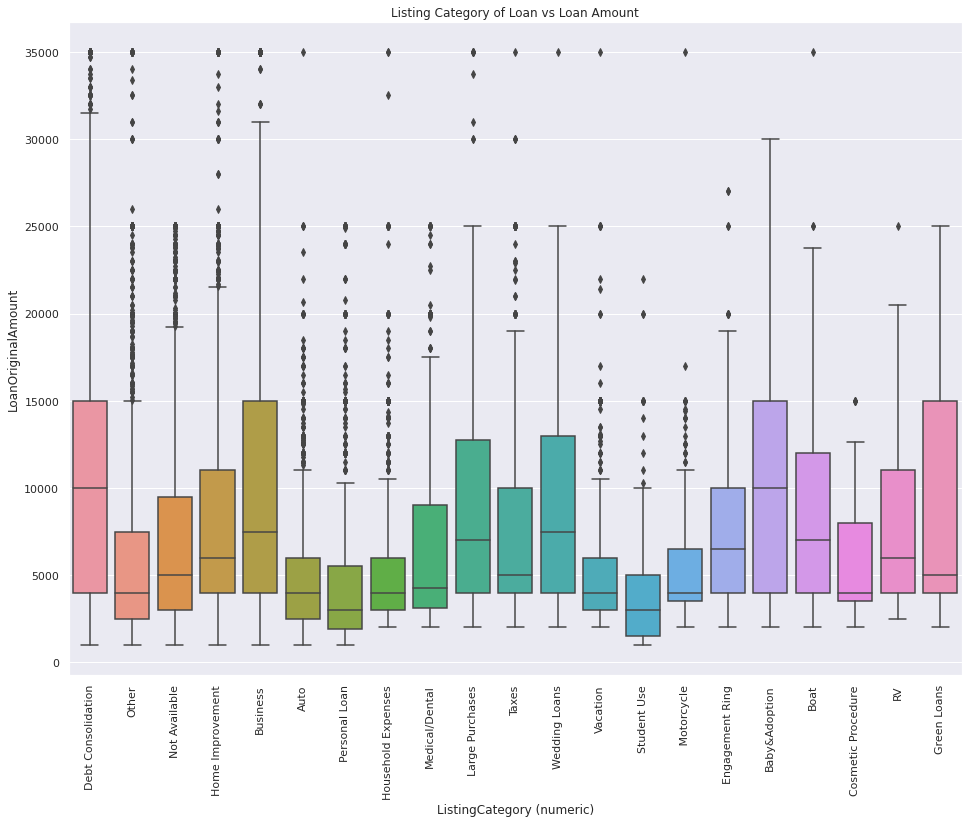

```python
#plotting a boxplot of Listing Category against Loan Amount
freq=loan['ListingCategory (numeric)'].value_counts()
gen_order=freq.index
plt.figure(figsize=(16,12))
loan['LoanOriginalAmount'] = loan['LoanOriginalAmount'].astype('float')
sb.boxplot(data =loan, x='ListingCategory (numeric)', y='LoanOriginalAmount', order=gen_order)
plt.title('Listing Category of Loan vs Loan Amount')
plt.xticks(rotation=90)
plt.show()
```

There's really no definite relationship between Loan Amount and Listing Category. According to the plot above, the highest amount of loans were borrowed for debt consolidation and baby and adoption while the lowest amount of loans were borrowed to cover personal loans and for student use.

```python
#getting the count of the values of some categorical
cat=['EmploymentStatus', 'ListingCategory (numeric)', 'IsBorrowerHomeowner']
for data in cat:
    print(loan[data].value_counts())
```

```
Employed         65895
Full-time        25484
Other             2194
Self-employed     1068
Part-time          955
Retired            734
Not employed        92
Name: EmploymentStatus, dtype: int64
Debt Consolidation    53513
Other                  9434
Not Available          9022
Home Improvement       6917
Business               5199
Auto                   2353
Personal Loan          2271
Household Expenses     1767
Medical/Dental         1382
Large Purchases         795
Taxes                   783
Wedding Loans           729
Vacation                712
Student Use             605
 Motorcycle             289
Engagement Ring         201
Baby&Adoption           191
Boat                     83
Cosmetic Procedure       82
RV                       49
Green Loans              45
Name: ListingCategory (numeric), dtype: int64
True     50949
False    45473
Name: IsBorrowerHomeowner, dtype: int64
```

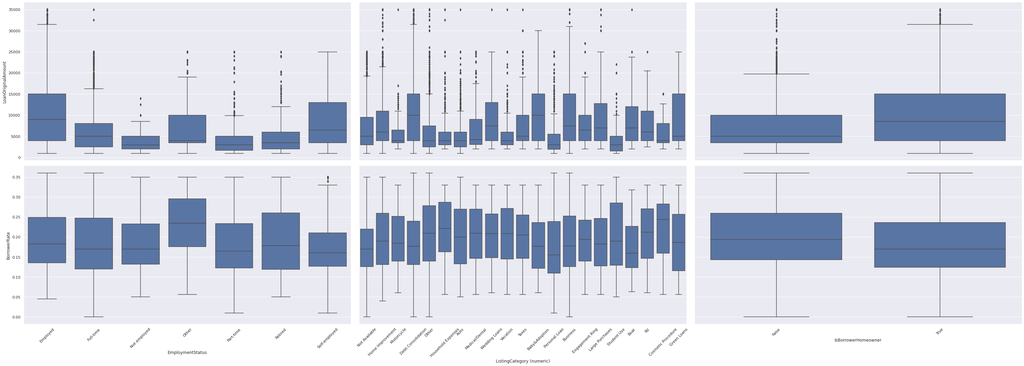

```python
# plot matrix of numeric features against categorical features.
# can use a larger sample since there are fewer plots and they're simpler in nature.

# Deprecated
# samples = np.random.choice(diamonds.shape[0], 2000, replace = False)
# diamonds_samp = diamonds.loc[samples,:]

#diamonds_samp = diamonds.sample(n=2000, replace = False)


def boxgrid(x, y, **kwargs):
    """ Quick hack for creating box plots with seaborn's PairGrid. """
    default_color = sb.color_palette()[0]
    sb.boxplot(x=x, y=y, color=default_color)

plt.figure(figsize = [10, 10])
g = sb.PairGrid(data = loan, y_vars = ['LoanOriginalAmount', 'BorrowerRate'], x_vars = ['EmploymentStatus', 'ListingCategory (numeric)',
                                                                                       'IsBorrowerHomeowner'],
                height = 7, aspect = 2.0)
g.map(boxgrid)
for ax in g.axes.flat:
    ax.set_xticklabels(ax.get_xticklabels(), rotation=45)
plt.show();
```

Employed Borrowers had the highest median loan amount, debt consolidation was a major reason borrowers borrowed a huge amount of money, borrowers with the highest median loan amount are actually home owners.

Borrower Rate was pretty high for borrowers who borrowed to cover household expenses, surprisingly, borrower rate was pretty high for borrowers who are not home owners.

```python
#grouping the numerical variables inside a list for easy looping through
numeric_vars = ['DebtToIncomeRatio', 'TotalProsperLoans', 'TotalProsperPaymentsBilled', 'CurrentDelinquencies',
                'EmploymentStatusDuration', 'CreditScoreRangeUpper', 'CreditScoreRangeLower', 'ProsperScore',
               'StatedMonthlyIncome', 'BorrowerRate', 'LoanOriginalAmount']
```

# Visualization

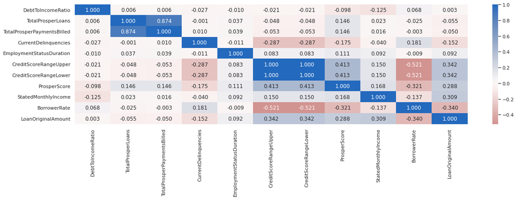

```python
# correlation plot
plt.figure(figsize = [20, 5])
sb.heatmap(loan[numeric_vars].corr(), annot = True, fmt = '.3f',
           cmap = 'vlag_r', center = 0)
plt.show()
```

```
loan.shape= (96422, 73)
loan_samp.shape= (500, 73)
```

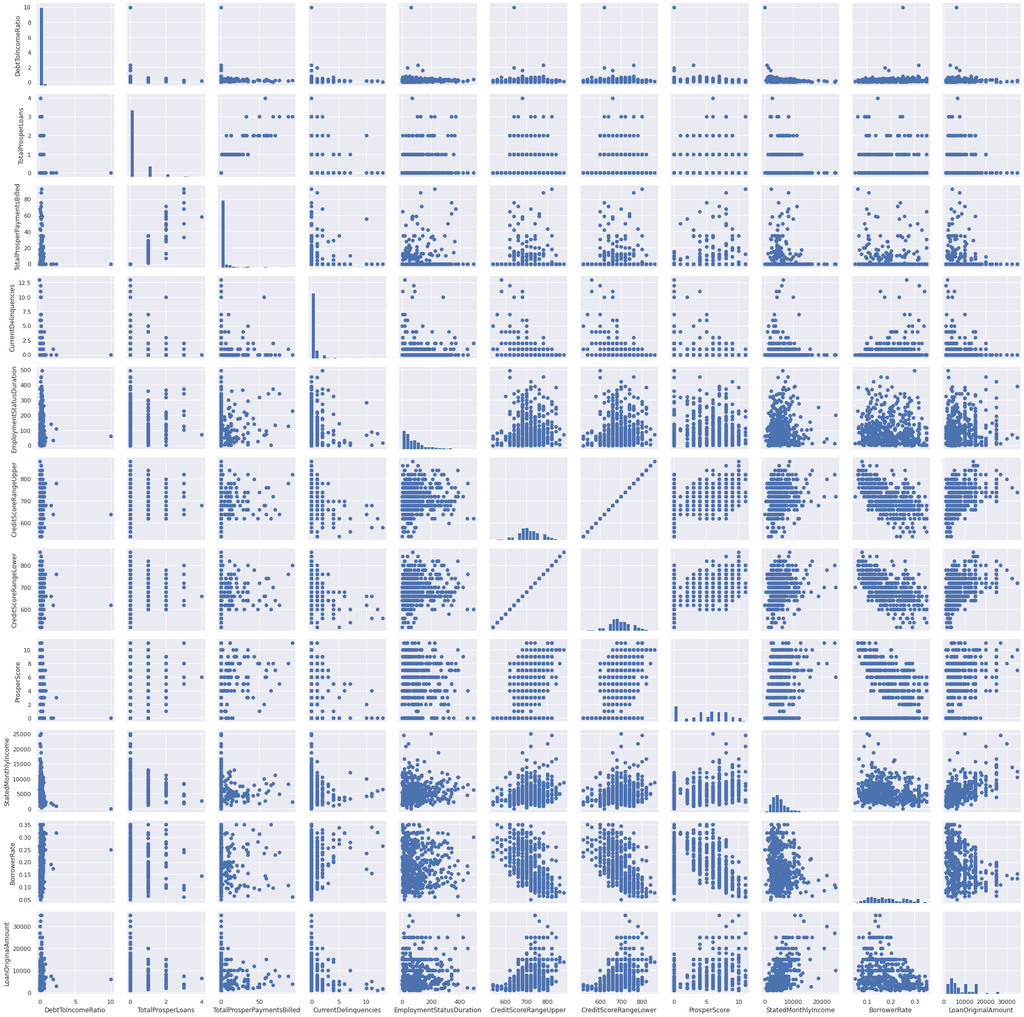

```python
# plot matrix: sample 500 loans so that plots are clearer and they render faster
print("loan.shape=",loan.shape)
loan_samp = loan.sample(n=500, replace = False)
print("loan_samp.shape=",loan_samp.shape)

g = sb.PairGrid(data = loan_samp, vars = numeric_vars)
g = g.map_diag(plt.hist, bins = 20);
g.map_offdiag(plt.scatter)
```

While some variables have little to no correlation with each other, others have pretty strong correlations. Using 30% as threshhold, these variables are positively correlated: TotalProsperLoans and TotalProsperPaymentsBilled ProsperScore and CreditScoreRangeUpper ProsperScore and CreditScoreRangeLower LoanOriginalAmount and CreditScoreRangeUpper LoanOriginalAmount and CreditScoreRangeLower LoanOriginalAmount and StatedMonthlyIncome

these variables are negatively correlated: Borrower Rate and CreditScoreRangeUpper Borrower Rate and CreditScoreRangeLower ProsperScore and Borrower Rate LoanOriginalAmount and Borrower Rate

[output not shown]

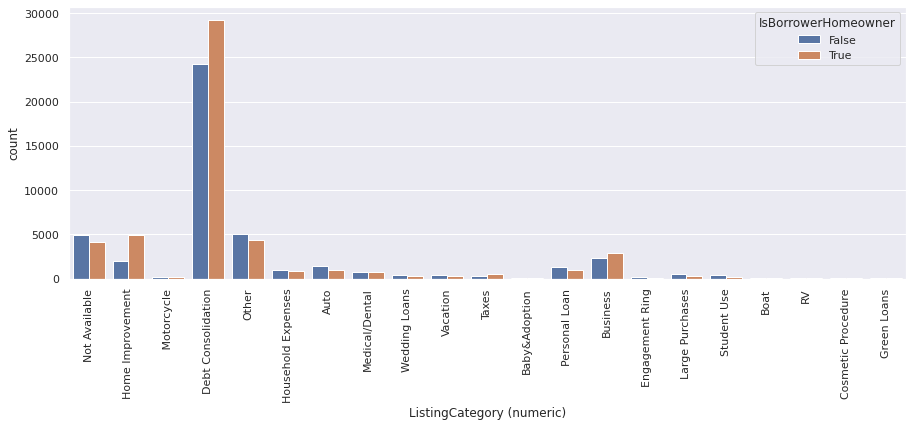

```python
plt.figure(figsize=[15,5])
sb.countplot(data = loan, x = 'ListingCategory (numeric)', hue = 'IsBorrowerHomeowner')
plt.xticks(rotation=90)
```

```python
#grouping Occupation column value names together inside of a list
students=['Student - Technical School', 'Student - Community College', 'Student - College Sophomore', 'Student - College Junior',
'Student - College Senior', 'Student - College Graduate Student', 'Student - College Freshman']
sales=['Sales - Retail', 'Sales - Commission']
engineer=['Engineer - Electrical', 'Engineer - Chemical', 'Engineer - Mechanical']
tradesman=['Tradesman - Carpenter', 'Tradesman - Plumber', 'Tradesman - Mechanic', 'Tradesman - Electrician']
nurse=['Nurse (RN)', 'Nurse (LPN)']
```

```python
#renaming values in Occupation column
for student in students:
    loan['Occupation'].replace(student, 'Student', inplace=True)
for sale in sales:
    loan['Occupation'].replace(sale, 'Sales', inplace=True)
for eng in engineer:
    loan['Occupation'].replace(eng, 'Engineer', inplace=True)
for trade in tradesman:
    loan['Occupation'].replace(trade, 'Tradesman', inplace=True)
for nur in nurse:
    loan['Occupation'].replace(nur, 'Nurse', inplace=True)
```

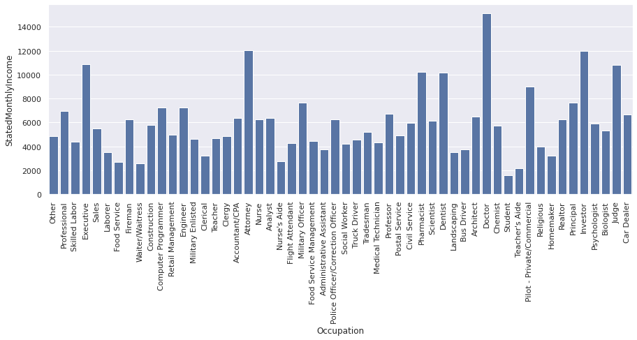

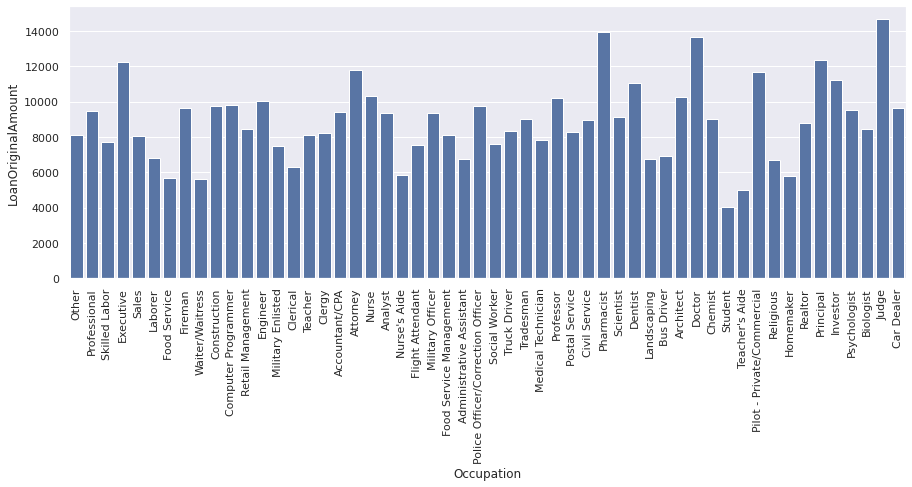

```python
base_color = sb.color_palette()[0]
plt.figure(figsize=[15,5])

# Get the indexes of the Series
sb.barplot(data=loan, x='Occupation', y='StatedMonthlyIncome', color=base_color, ci=None)
plt.xticks(rotation=90);

base_color = sb.color_palette()[0]
plt.figure(figsize=[15,5])

# Get the indexes of the Series
sb.barplot(data=loan, x='Occupation', y='LoanOriginalAmount', color=base_color, ci=None)
plt.xticks(rotation=90);
```

### Did you observe any interesting relationships between the other features (not the main feature(s) of interest)?

> For other features, a strong positive correlation was found between these features: TotalProsperLoans and TotalProsperPaymentsBilled ProsperScore and CreditScoreRangeUpper ProsperScore and CreditScoreRangeLower

## Multivariate Exploration

> Create plots of three or more variables to investigate your data even further. Make sure that your investigations are justified, and follow from your work in the previous sections.

```python
loan['Occupation'].value_counts()
```

```
Other                                23730
Professional                         12325
Sales                                 5027
Computer Programmer                   3992
Executive                             3856
Teacher                               3478
Analyst                               3385
Administrative Assistant              3377
Accountant/CPA                        2944
Nurse                                 2859
Clerical                              2795
Engineer                              2584
Skilled Labor                         2483
Retail Management                     2359
Police Officer/Correction Officer     1524
Tradesman                             1475
Truck Driver                          1461
Laborer                               1445
Civil Service                         1401
Construction                          1380
Military Enlisted                     1150
Food Service Management               1124
Medical Technician                    1041
Food Service                           939
Attorney                               851
Social Worker                          691
Postal Service                         593
Professor                              517
Student                                434
Nurse's Aide                           430
Doctor                                 418
Fireman                                398
Waiter/Waitress                        363
Scientist                              342
Military Officer                       326
Bus Driver                             297
Principal                              287
Realtor                                271
Teacher's Aide                         249
Pharmacist                             245
Architect                              186
Pilot - Private/Commercial             184
Clergy                                 171
Car Dealer                             144
Chemist                                139
Landscaping                            125
Biologist                              120
Flight Attendant                       117
Psychologist                           108
Religious                               95
Investor                                66
Dentist                                 56
Homemaker                               43
Judge                                   22
Name: Occupation, dtype: int64
```

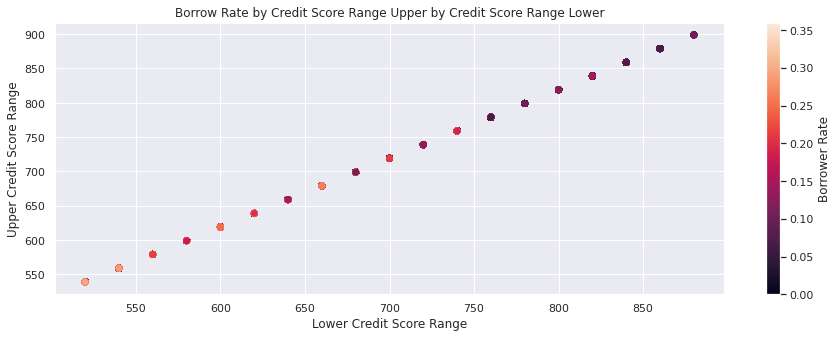

```python
#plotting scatter plot of credit score ranges against borrower rate
plt.figure(figsize=[15,5])
plt.scatter(data = loan, x = 'CreditScoreRangeLower', y = 'CreditScoreRangeUpper', c = 'BorrowerRate')
plt.xlabel('Lower Credit Score Range')
plt.ylabel('Upper Credit Score Range')
plt.title('Borrow Rate by Credit Score Range Upper by Credit Score Range Lower')
plt.colorbar(label='Borrower Rate')
```

The chart above shows that with an increase in credit score range, both upper and lower, there is a decrease in the borrower rate i.e since borrowers with higher credit scores are more likely to repay their debts on time, then their borrower rate definitely decreases.

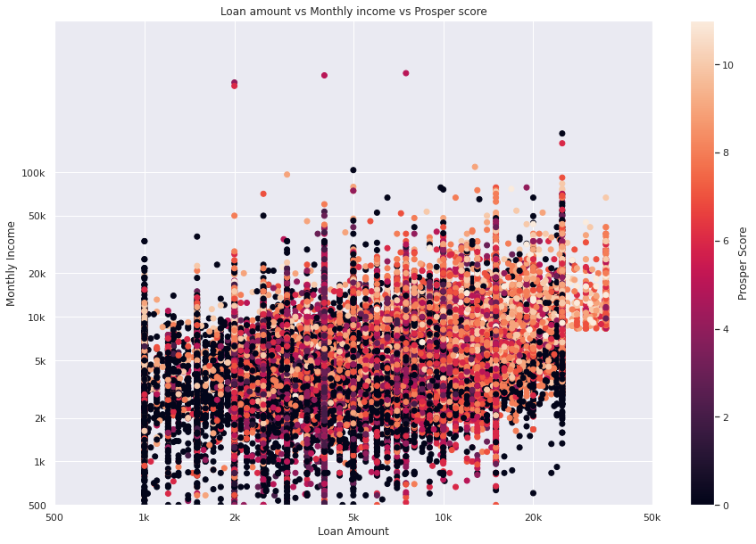

```python
#plotting scatter plot of loan amount, monthly income, prosper score
plt.figure(figsize=[15,10])
plt.scatter(data = loan, x = 'LoanOriginalAmount', y = 'StatedMonthlyIncome', c = 'ProsperScore')
plt.xscale('log')
plt.xticks([500, 1e3, 2e3, 5e3, 1e4, 2e4, 5e4], [500, '1k', '2k', '5k', '10k', '20k', '50k'])
plt.yscale('log')
plt.yticks([500, 1e3, 2e3, 5e3, 1e4, 2e4, 5e4, 10e4], [500, '1k', '2k', '5k', '10k', '20k', '50k', '100k'])
plt.title('Loan amount vs Monthly income vs Prosper score')
plt.xlabel("Loan Amount")
plt.ylabel("Monthly Income")
plt.colorbar(label='Prosper Score')
```

```python
loan['LoanStatusCopy'].value_counts()
```

```
Current       51170
Completed     30769
Chargedoff     9398
Defaulted      3054
Past Due       1829
Cancelled         1
Name: LoanStatusCopy, dtype: int64
```

The borrowers with high prosper scores are on the top right. They generally have higher monthly income and larger loan amounts.

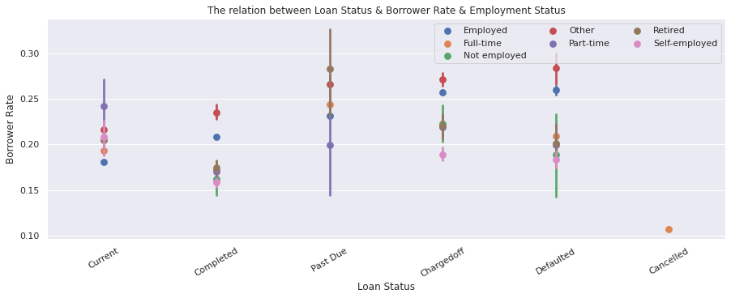

```python
plt.figure(figsize=[15,5])
sb.pointplot(data=loan,x="LoanStatusCopy",y="BorrowerRate",hue="EmploymentStatus",linestyles="",
            order=['Current', 'Completed', 'Past Due', 'Chargedoff', 'Defaulted', 'Cancelled']);
plt.xticks(rotation =30);
plt.legend(ncol=3);

plt.ylabel("Borrower Rate")
plt.xlabel("Loan Status");
plt.title("The relation between Loan Status & Borrower Rate & Employment Status");
```

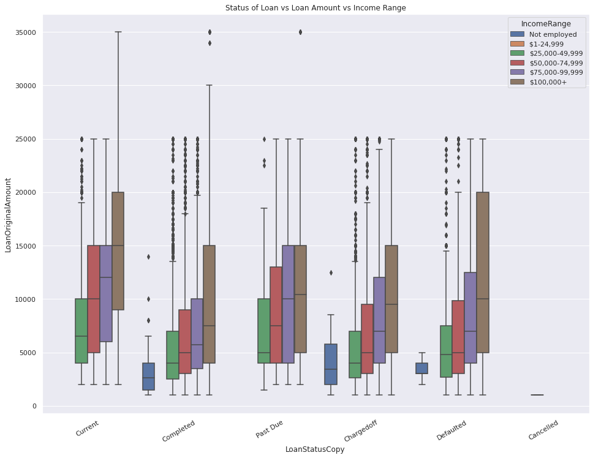

```python
#plotting a boxplot of Listing Category against Loan Amount
plt.figure(figsize=(16,12))
loan['LoanOriginalAmount'] = loan['LoanOriginalAmount'].astype('float')
sb.boxplot(data =loan, x='LoanStatusCopy', y='LoanOriginalAmount', hue='IncomeRange',
           order=['Current', 'Completed', 'Past Due', 'Chargedoff', 'Defaulted', 'Cancelled'])
plt.title('Status of Loan vs Loan Amount vs Income Range')
plt.xticks(rotation=30)
plt.show()
```

The chart above is quite interesting because it shows a good correlation between Income Range and Loan Amount, the higher the income range, the higher the loan amount the borrowers were likely to take.

### Talk about some of the relationships you observed in this part of the investigation. Were there features that strengthened each other in terms of looking at your feature(s) of interest?

> After seeing the strong correlation between CreditScore Range Upper and Lower and borrower rate, I decided to pry further and indeed i discovered a strong negative correlation between the three because with an increase in credit score range, both upper and lower, there is an equivalent decrease in the borrower rate.

> I also discovered the relationship between Loan Amount, prosper score and monthly Income. High Income earners borrowed higher amount of loan which lead to the increase in prosper score. This accounts for the correlation between the three. Also, there was an increase in loan amount as the income range of borrowers increased.

## Conclusions

> You can write a summary of the main findings and reflect on the steps taken during the data exploration.

> In the exploration, I found that there was a strong relationship between the borrower rate of a borrower and his/her upper and lower credit score score range. The relationship between credit score ranges and borrower rate was found to be an approximately linear one. For the Loan Amount, after initially plotting with a standard scale, I couldn't clearly see the relationship it had with prosper score and Monthly income but after a log-scaling, the plotting became clearer as I was able to discover the positive correlation with both monthly income and prosper score. Not to put away the fact that Income range also shared a positive relationship with loan amount.

> Remove all Tips mentioned above, before you convert this notebook to PDF/HTML

> At the end of your report, make sure that you export the notebook as an html file from the `File > Download as... > HTML or PDF` menu. Make sure you keep track of where the exported file goes, so you can put it in the same folder as this notebook for project submission. Also, make sure you remove all of the quote-formatted guide notes like this one before you finish your report!